# iFood - Customer Segmentation

# Problem

The data set contains sociodemographic and firmographic features about 2.240 customers who were contacted. Additionally, it contains a flag for those customers who responded the campaign, by buying the product.

- In this project, the RFM calculation is made in order to understand how customers should be classified.
- Afterwards a predictive classification model is made using the Naive Bayes algorithm.

# RFM

```r
# value spent on products
dados$mont <- dados$MntFishProducts+dados$MntFruits+dados$MntGoldProds+
              dados$MntMeatProducts+dados$MntSweetProducts+dados$MntWines

# amount of purchases
dados$num <- dados$NumCatalogPurchases+dados$NumDealsPurchases+
             dados$NumStorePurchases+dados$NumWebPurchases

customers_RFM = sqldf(
    "SELECT ID,
            MIN(Recency) AS 'Recency',
            Sum(num) AS 'Frequency',
            SUM(mont) AS 'Monetary'
        FROM dados
        GROUP BY 1"
)

customers_RFM %>%
  head(10) %>%
      formattable::formattable()
```

| ID | Recency | Frequency | Monetary |
| --- | --- | --- | --- |
| 0 | 66 | 17 | 1198 |
| 1 | 0 | 18 | 577 |
| 9 | 86 | 11 | 120 |
| 13 | 57 | 6 | 32 |
| 17 | 81 | 28 | 1028 |
| 20 | 91 | 8 | 183 |
| 22 | 99 | 14 | 309 |
| 24 | 96 | 12 | 47 |
| 25 | 9 | 21 | 1115 |
| 35 | 35 | 10 | 210 |

# Histograms

To evaluate the distribution of the RFM parameters we can use the histogram.

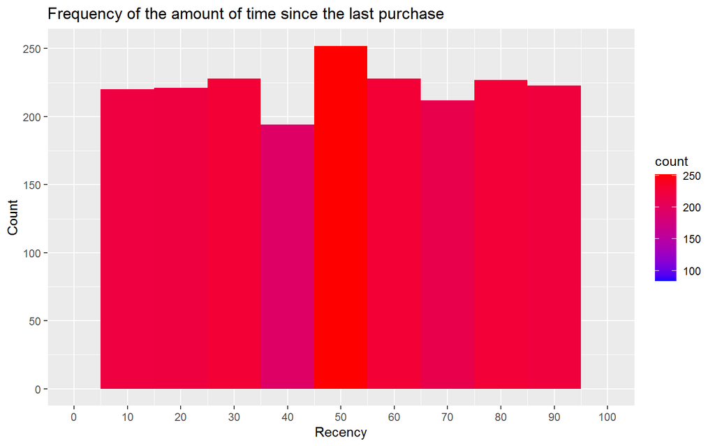

```r
# Recency
ggplot(customers_RFM, aes(x = Recency)) +
        geom_histogram(aes(fill = ..count..), binwidth = 10) +
        scale_x_continuous(name = "Recency",
                           breaks = seq(0, 100, 10),
                           limits=c(0, 100)) +
        scale_y_continuous(name = "Count") +
        scale_fill_gradient(low="blue", high="red") +
        ggtitle("Frequency of the amount of time since the last purchase")
```

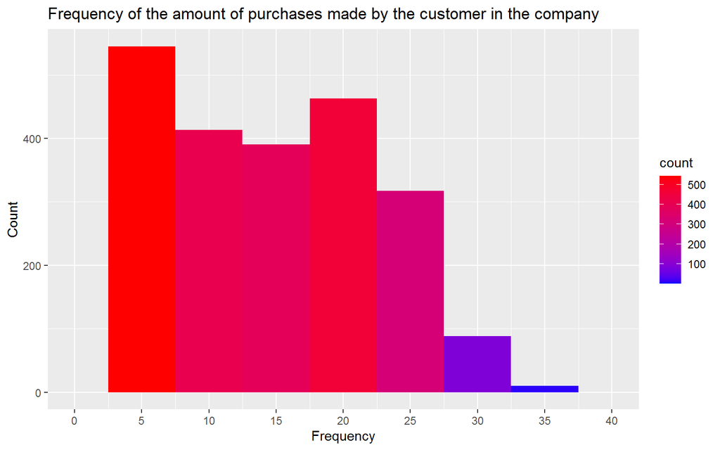

```r
# Frequency
ggplot(customers_RFM, aes(x = Frequency)) +
        geom_histogram(aes(fill = ..count..), binwidth = 5) +
        scale_x_continuous(name = "Frequency",
                           breaks = seq(0, 40, 5),
                           limits=c(0, 40)) +
        scale_y_continuous(name = "Count") +
        scale_fill_gradient(low="blue", high="red") +
        ggtitle("Frequency of the amount of purchases made by the customer in the company")
```

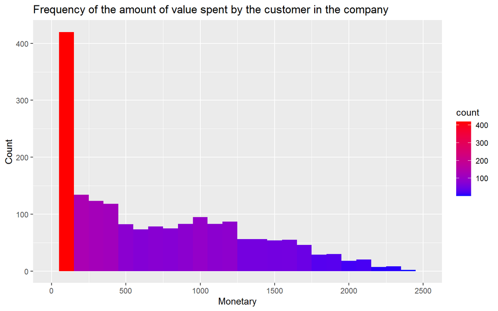

```r
# Monetary
ggplot(customers_RFM, aes(x = Monetary)) +
        geom_histogram(aes(fill = ..count..), binwidth = 100) +
        scale_x_continuous(name = "Monetary",
                           breaks = seq(0, 2500, 500),
                           limits=c(0, 2500)) +
        scale_y_continuous(name = "Count") +
        scale_fill_gradient(low="blue", high="red") +
        ggtitle("Frequency of the amount of value spent by the customer in the company")
```

# Percentile

```r
quantile(customers_RFM$Recency, probs = seq(0, 1, 0.20)) %>% pander()
```

| 0% | 20% | 40% | 60% | 80% | 100% |
| --- | --- | --- | --- | --- | --- |
| 0 | 19 | 39 | 59 | 79 | 99 |

Analyzing how many days was the customer’s last purchase, we can see that:

- Top20 customers bought in the last 19 days;
- The next 20% of customers bought between 19 and 39 days;
- Whereas the last 20% of customers spend more than 79 days without making any purchases.

```r
quantile(customers_RFM$Frequency, probs = seq(0, 1, 0.20)) %>% pander()
```

| 0% | 20% | 40% | 60% | 80% | 100% |
| --- | --- | --- | --- | --- | --- |
| 0 | 7 | 11 | 17 | 22 | 44 |

As for the frequency with which they make purchases, we can see that:

- Top20 customers bought more than 22 times over the period under review;
- The following 20% of customers bought between 17 and 22 times;
- The last 20% of customers bought 7 times in the period under review.

```r
quantile(customers_RFM$Monetary, probs = seq(0, 1, 0.20)) %>% pander()
```

| 0% | 20% | 40% | 60% | 80% | 100% |
| --- | --- | --- | --- | --- | --- |
| 5 | 55 | 194.6 | 635.4 | 1174 | 2525 |

As for the amount spent by the customer, we can see that:

- Top20 customers spend on average more than 1174.00 u.m (currency unit);
- The next 20% spend between 635.4 and 1174.00 u.m, while the last 20% of customers spend less than 55.00 u.m in their average consumption.

# RFM score

```r
rfm_data <- customers_RFM

rfm_data <-
    rfm_data %>%
    mutate(
        R = ntile(desc(Recency), 5),
        F = ntile(Frequency, 5),
        M = ntile(Monetary, 5)
    )

rfm_data$RFM <- rfm_data$R * 100 + rfm_data$F * 10 + rfm_data$M

rfm_data %>%
  head(10) %>%
      formattable::formattable()
```

| ID | Recency | Frequency | Monetary | R | F | M | RFM |
| --- | --- | --- | --- | --- | --- | --- | --- |
| 0 | 66 | 17 | 1198 | 2 | 3 | 5 | 235 |
| 1 | 0 | 18 | 577 | 5 | 4 | 3 | 543 |
| 9 | 86 | 11 | 120 | 1 | 2 | 2 | 122 |
| 13 | 57 | 6 | 32 | 3 | 1 | 1 | 311 |
| 17 | 81 | 28 | 1028 | 1 | 5 | 4 | 154 |
| 20 | 91 | 8 | 183 | 1 | 2 | 2 | 122 |
| 22 | 99 | 14 | 309 | 1 | 3 | 3 | 133 |
| 24 | 96 | 12 | 47 | 1 | 3 | 1 | 131 |
| 25 | 9 | 21 | 1115 | 5 | 4 | 4 | 544 |
| 35 | 35 | 10 | 210 | 4 | 2 | 3 | 423 |

Note that customers with a high RFM score have low values for the variable Recency and high for the variables Frequency and Monetary, for example ID = 25, while customers with a low RFM score, show high values for the variable Recency and high for Frequency, for example ID = 17. Being that, for customers with intermediate RFM score values they need a more careful analysis. As will be seen below.

# Customer Segmentation

```r
rfm_data$segment <- NA

rfm_data$segment[which(rfm_data$RFM == 111)] <- 'Lost'
rfm_data$segment[which(rfm_data$RFM > 111)] <- 'Hibernating'

rfm_data$segment[which(rfm_data$RFM >= 222)] <- 'About to sleep'

rfm_data$segment[which(rfm_data$RFM >= 333)] <- 'Potential loyalist'

rfm_data$segment[which(rfm_data$RFM >= 444)] <- 'Champion'


# 2nd round
rfm_data$segment[which(rfm_data$segment == 'Potential loyalist' &
                           (rfm_data$F >= 4))] <- 'Loyal customer'

rfm_data$segment[which(rfm_data$segment == 'About to sleep' &
                           (rfm_data$M >= 4))] <-'Needing attention'

rfm_data$segment[which(rfm_data$segment == 'Hibernating' &
                           (rfm_data$F >= 4 & rfm_data$M >= 4))] <-'Can not lose them'

rfm_data[, -c(5, 6,7)] %>%
    head(10) %>%
    formattable::formattable()
```

| ID | Recency | Frequency | Monetary | RFM | segment |
| --- | --- | --- | --- | --- | --- |
| 0 | 66 | 17 | 1198 | 235 | Needing attention |
| 1 | 0 | 18 | 577 | 543 | Champion |
| 9 | 86 | 11 | 120 | 122 | Hibernating |
| 13 | 57 | 6 | 32 | 311 | About to sleep |
| 17 | 81 | 28 | 1028 | 154 | Can not lose them |
| 20 | 91 | 8 | 183 | 122 | Hibernating |
| 22 | 99 | 14 | 309 | 133 | Hibernating |
| 24 | 96 | 12 | 47 | 131 | Hibernating |
| 25 | 9 | 21 | 1115 | 544 | Champion |
| 35 | 35 | 10 | 210 | 423 | Potential loyalist |

# Distribution of customers by segments

```r
rfm_data$segment <-
    factor(
        x = rfm_data$segment,
        levels = c(
            'Lost',
            'Hibernating',
            'Can not lose them',
            'About to sleep',
            'Needing attention',
            'New Customer',
            'Potential loyalist',
            'Loyal customer',
            'Champion'
        )
    )


# frequency table
freqTable <-
    rfm_data %>%
    # group_by(group) %>%
    count(segment) %>%
    # arrange(desc(n)) %>%
    rename(Segment = segment, Count = n)

freqTable %>%
      formattable::formattable()
```

| Segment | Count |
| --- | --- |
| Lost | 68 |
| Hibernating | 322 |
| Can not lose them | 156 |
| About to sleep | 351 |
| Needing attention | 193 |
| Potential loyalist | 345 |
| Loyal customer | 207 |
| Champion | 598 |

```r
# or grouped
cust_aggr_dat <-
    aggregate(x = rfm_data[, 2:4],
              by = list(rfm_data$segment),
              mean)


cust_aggr_dat %>%
      formattable::formattable()
```

| Group.1 | Recency | Frequency | Monetary |
| --- | --- | --- | --- |
| Lost | 88.29412 | 4.852941 | 31.98529 |
| Hibernating | 83.49379 | 10.046584 | 236.57764 |
| Can not lose them | 89.33974 | 23.192308 | 1252.18590 |
| About to sleep | 57.98006 | 10.034188 | 163.23077 |
| Needing attention | 68.70984 | 21.119171 | 1272.25907 |
| Potential loyalist | 33.21739 | 10.817391 | 357.40580 |
| Loyal customer | 47.41063 | 22.429952 | 1029.28986 |
| Champion | 13.86789 | 16.948161 | 742.61873 |

The results show that:

# Data visualization

```r
# tree map
hctreemap2(
    data = freqTable,
    group_vars = "Segment",
    size_var = "Count",
    color_var = "Count"
    )
```

[interactive chart not shown]

```r
# bar graph
highchart() %>%
    hc_add_series(
        data = freqTable,
        type = 'column',
        hcaes(x = Segment, y = Count),
        dataLabels = list(align = "center", enabled = TRUE,
                          style = list(
                                      fontWeight = "bold",
                                      color = "#f7a35c",
                                      textOutline = NULL
                                      )
                          ),
        name = 'Segments'
    ) %>%
    hc_xAxis(categories = unique(freqTable$Segment)) %>%
    hc_yAxis(title = list(text = "Clients"))
```

[interactive chart not shown]

Customers in the Champions segment are considered to be the most valuable and About to sleep and Needing attention, need some special attention to rescue them.

# Applying the Naive Bayes algorithm

I chose the Naive Bayes algorithm, because it disregards correlations between variables, treating each variable independently. This algorithm is also faster to implement than for example an SVM algorithm and in addition to not needing a lot of data to make the classification.

# Confusion Matrix

```r
matriz_confusao = table(base_teste[, 25], predictions)

confusionMatrix(matriz_confusao)
```

```
## Confusion Matrix and Statistics
##
##    predictions
##       0   1
##   0 449  22
##   1  16  67
##
##                Accuracy : 0.9314
##                  95% CI : (0.9071, 0.951)
##     No Information Rate : 0.8394
##     P-Value [Acc > NIR] : 5.688e-11
##
##                   Kappa : 0.7385
##
##  Mcnemar's Test P-Value : 0.4173
##
##             Sensitivity : 0.9656
##             Specificity : 0.7528
##          Pos Pred Value : 0.9533
##          Neg Pred Value : 0.8072
##              Prevalence : 0.8394
##          Detection Rate : 0.8105
##    Detection Prevalence : 0.8502
##       Balanced Accuracy : 0.8592
##
##        'Positive' Class : 0
##
```

Analyzing the confusion matrix, in class 0 (customer did not buy the offer) the algorithm correctly classified 449 observations and incorrectly 22 observations, in class 1 (customer bought the offer) the algorithm correctly classified 67 observations and incorrectly 16 observations. In both classes, the algorithm was more than right.

Model accuracy was 93.14%.

# Making predictions

```r
dados[, -c(2:25)] %>%
    head(28) %>%
   pander()
```

|  | ID | Response | predictions |
| --- | --- | --- | --- |
| **1** | 5524 | 1 | 0 |
| **2** | 2174 | 0 | 0 |
| **3** | 4141 | 0 | 0 |
| **4** | 6182 | 0 | 0 |
| **5** | 5324 | 0 | 0 |
| **6** | 7446 | 0 | 0 |
| **7** | 965 | 0 | 0 |
| **8** | 6177 | 0 | 0 |
| **9** | 4855 | 1 | 0 |
| **10** | 5899 | 0 | 0 |
| **12** | 387 | 0 | 0 |
| **13** | 2125 | 0 | 0 |
| **14** | 8180 | 0 | 1 |
| **15** | 2569 | 0 | 0 |
| **16** | 2114 | 1 | 0 |
| **17** | 9736 | 0 | 0 |
| **18** | 4939 | 0 | 0 |
| **19** | 6565 | 0 | 0 |
| **20** | 2278 | 0 | 1 |
| **21** | 9360 | 0 | 0 |
| **22** | 5376 | 0 | 0 |
| **23** | 1993 | 0 | 0 |
| **24** | 4047 | 0 | 0 |
| **25** | 1409 | 0 | 0 |
| **26** | 7892 | 0 | 0 |
| **27** | 2404 | 0 | 0 |
| **29** | 9422 | 0 | 0 |
| **30** | 1966 | 0 | 1 |